# R_learning_iml_5

Hector Hao

2019/5/2

# 第二章 黑箱模型解释 Model-Agnostic Methods

### PART 1. 特征层面的模型解释.

## 这种模型在解释方面的优势主要是灵活性。

### partial dependence plot(pdp)

#### 见plotmo pmethod = “partdep” 但是这个方法貌似不如iml的feature effect的ale plot(accumulated local effect).

```r
# 用于相关分析
library(PerformanceAnalytics)
```

下面的封装方式基本是固定的。这里可以体会一下黑箱模型画图的优劣势。

前面提到了优势是灵活性，可以在不知道模型具体结构的情况下把图画出来。

但是也会有相应的缺点。所有的数据点是重新输入进去然后计算了一遍的。

在数据量大的时候要注意。

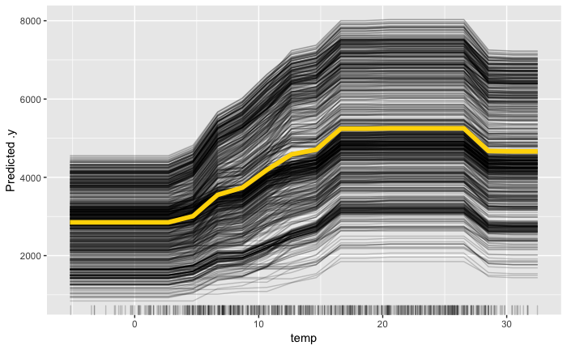

以及在上图中，还要注意数据点的分布。否则很多时候所谓的“趋势”是假的

|  | plotmo grid: season | yr | mnth | holiday | weekday | workingday | weathersit | temp | hum | windspeed | days_since_2011 |
| --- | --- | --- | --- | --- | --- | --- | --- | --- | --- | --- | --- |
|  | FALL | 2012 | JAN | NO HOLIDAY | SUN | WORKING DAY | GOOD | 15.42165 | 62.6667 | 12.12533 | 365 |

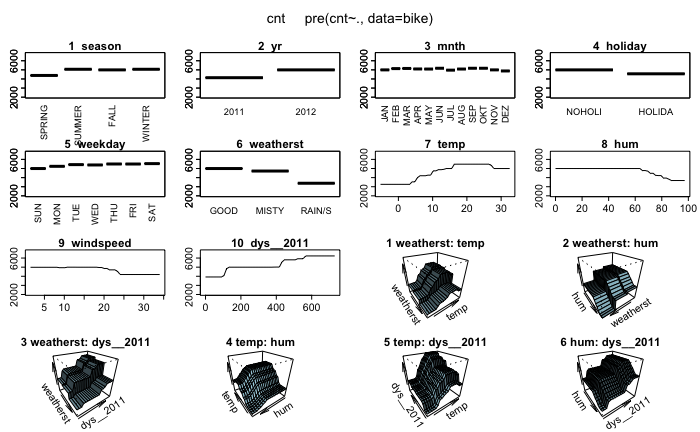

### individual conditional expectation(ICE)

- 在ICE中，每个实例有一条线。表现的是随着横轴的变量变化，每个实例的变化趋势。

```r
# 图见上面的feaeff.
```

### accumulated local effect(ale)

- 一阶 ale 不难理解，就是加了条件分布的单变量趋势图。
- 二阶 ale 需要注意。二阶ale只会显示二阶效果，不会显示一阶主效应。

这里给出实例。

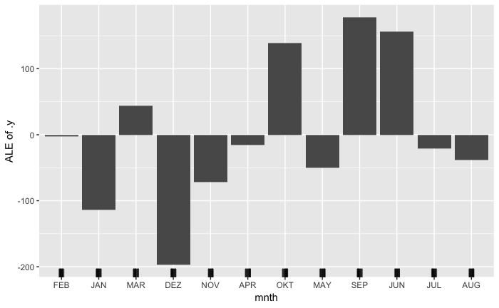

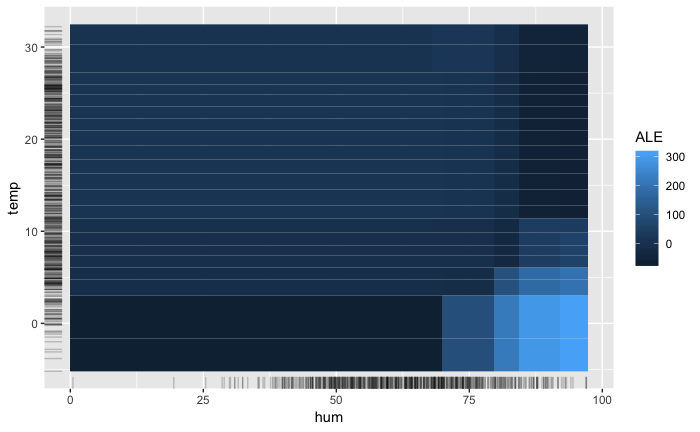

还可以试一试ALEPlot的效果

上面提到了变量的相关性，这里给了几个求相关的可视化方法。

```r
library(Hmisc)
library(ggcorrplot)


#create correlation matrix
cor_ret = rcorr(as.matrix(bike[sapply(bike, is.numeric)]), type = c("pearson"))

ggcorrplot(cor_ret$r, hc.order = TRUE, type = "lower",
     outline.col = "white", p.mat = cor_ret$P, insig = "blank")
```

[output not shown]